# INFO 370 Data Assignment 1: Interrogating Birth Data

Published

October 6, 2024

# Assignment Overview

In this assignment, you will look at 2018 United States birth records, provided by the National Center for Vital Statistics. You will:

- Conduct basic data wrangling with a moderately big data set
- Create visualizations for core data visualization types
- Contextualize the data in descriptions, causal understanding, and prediction tasks
- Consider some ethical issues involved in using public health data collected by the government

Before you complete this assignment. You must check out the data use restrictions listed [here](https://wonder.cdc.gov/natality-current.html). Once you have read those restrictions and agreed to them, then fill in your name below.

**Note**

To complete this assignment, you will need to write code or text for each of the exercises below. Make sure to work from top to bottom to complete the assignment. For specific R code issues, feel free to consult outside resources, in particular the R4DS textbook chapters on [data transformation](https://r4ds.hadley.nz/data-transform) and [data visualization](https://r4ds.hadley.nz/data-visualize).

**Warning**

Making inferences or forming predictions about newborn birth weight (and other features in pregnancy and birth) is complex, and an area of intense research in many different disciplines. Nothing you are able to see in this data given our current skills in this class is sufficient to form reasonable, justified beliefs about health.

# The Data Setup

The following sections of the report set up the environment for you to create visualizations.

## Load Libraries

Set up the libraries required for visualizations.

## Load Data

To load the data, make sure you saved the .Rdata file in the same location as this Quarto file.

Have a look at the variables recorded in this dataset. Each row represents one live childbirth and features of the parents and pregnancy that led to it.

```
Rows: 3,801,534
Columns: 37
$ dbwt      <dbl> 3657, 3242, 3470, 3140, 2125, 4082, 3180, 3230, 3700, 3430, …
$ bwtr4     <fct> Normal, Normal, Normal, Normal, LBW, Normal, Normal, Normal,…
$ mracehisp <fct> NH White, NH Other, NH White, NH Other, NH White, NH White, …
$ fracehisp <fct> Hispanic, NH Other, NH White, NH Other, NH Black, Hispanic, …
$ dmar      <fct> Married, Unmarried, Married, Unmarried, Married, Married, Ma…
$ meduc     <fct> Bachelor, NA, Bachelor, <HS, Some college, Bachelor, Some co…
$ feduc     <fct> HS, Some college, Some college, <HS, HS, Bachelor, Bachelor,…
$ mager     <dbl> 30, 35, 28, 23, 37, 26, 28, 31, 37, 26, 25, 27, 29, 30, 36, …
$ fagecomb  <dbl> 31, 35, 31, 26, 35, 28, 25, 29, 42, 28, 26, 26, 37, 31, 40, …
$ priorlive <dbl> 1, 2, 1, 2, 1, 1, 2, 0, 2, 0, 2, 0, 3, 1, 3, 2, 3, 0, 2, 1, …
$ priordead <dbl> 0, 0, 0, 0, 0, 0, 0, 0, 0, 0, 0, 0, 0, 0, 0, 0, 1, 0, 0, 0, …
$ priorterm <dbl> 2, 0, 0, 0, 4, 0, 0, 0, 0, 0, 1, 0, 0, 0, 0, 2, 1, 0, 0, 2, …
$ lbo_rec   <dbl> 2, 3, 2, 3, 2, 2, 3, 1, 3, 1, 3, 1, 4, 2, 4, 3, 5, 1, 3, 2, …
```

[output cut: 24 more lines]

### Data Dictionary

This data set includes a lot of features about US births (and this is already trimmed from the full US natality data set available online). This document won’t go into too many details, but a lot more can be found at the website for the [National Center for Health Statistics](https://www.cdc.gov/nchs/data_access/vitalstatsonline.htm). Here are some features to consider in particular:

- dbwt - the weight of a live newborn in grams
- bwtr4 - this is a categorical label that describes if a newborn is described as “low birth weight” (less than 2,500 grams) or “very low birth weight” (less than 1,500 grams). [This article](https://www.childrenshospital.org/conditions/low-birthweight-newborns) published by the Boston Children’s hospital describes these categories and some reasons why physicians and parents may be interested in them.
- preterm - this is a designation of whether or not a newborn is a “premie” or born before the normative 37 week cutoff for “normal” pregnancy length. [Here](https://www.mayoclinic.org/diseases-conditions/premature-birth/symptoms-causes/syc-20376730) is some information on why physicians and parents might be concerned about preterm status of newborns.
- wic - a recording of whether of not a mother was enrolled in the US federal government’s Special Supplemental Nutrition Program for Women, Infants, and Children (usually called WIC, said like “wick”). This is a program that offers healthcare and nutrition assistance to low-income, pregnant and breastfeeding women.
- cig_rec - a label that loosely describes if a mother consumed tobacco cigarettes during pregnancy. This collapses over frequency and doesn’t distinguish between early and later pregnancy
- dplural - this describes if a newborn was single or a member of a set of twins, triplets, quadruplets, etc.
- sex - the sex determination made for a newborn, typically based on morphological or anatomical features of a newborn. Note that the NCHS only records female or male as options. Physicians or parents make a determination to choose a category for each newborn – this is a complicated and contentious process, and especially so in cases where infants are intersex

## Cleaning the Data

### Exercise 1: Filter the data (1 pt)

Filter the data so that it only includes cases of single newborns, excluding twins, triplets, etc. Save over the births data frame with the result and glimpse the resulting data.

```
Rows: 3,674,115
Columns: 37
$ dbwt      <dbl> 3657, 3242, 3470, 3140, 2125, 4082, 3180, 3230, 3700, 3430, …
$ bwtr4     <fct> Normal, Normal, Normal, Normal, LBW, Normal, Normal, Normal,…
$ mracehisp <fct> NH White, NH Other, NH White, NH Other, NH White, NH White, …
$ fracehisp <fct> Hispanic, NH Other, NH White, NH Other, NH Black, Hispanic, …
$ dmar      <fct> Married, Unmarried, Married, Unmarried, Married, Married, Ma…
$ meduc     <fct> Bachelor, NA, Bachelor, <HS, Some college, Bachelor, Some co…
$ feduc     <fct> HS, Some college, Some college, <HS, HS, Bachelor, Bachelor,…
$ mager     <dbl> 30, 35, 28, 23, 37, 26, 28, 31, 37, 26, 25, 27, 29, 30, 36, …
$ fagecomb  <dbl> 31, 35, 31, 26, 35, 28, 25, 29, 42, 28, 26, 26, 37, 31, 40, …
$ priorlive <dbl> 1, 2, 1, 2, 1, 1, 2, 0, 2, 0, 2, 0, 3, 1, 3, 2, 3, 0, 2, 1, …
$ priordead <dbl> 0, 0, 0, 0, 0, 0, 0, 0, 0, 0, 0, 0, 0, 0, 0, 0, 1, 0, 0, 0, …
$ priorterm <dbl> 2, 0, 0, 0, 4, 0, 0, 0, 0, 0, 1, 0, 0, 0, 0, 2, 1, 0, 0, 2, …
$ lbo_rec   <dbl> 2, 3, 2, 3, 2, 2, 3, 1, 3, 1, 3, 1, 4, 2, 4, 3, 5, 1, 3, 2, …
```

[output cut: 24 more lines]

### Exercise 2: Select relevant features (1 pt)

Trim down the births data frame so that it includes only features to consider later. Specifically, include only dbwt, wic, cig_rec, preterm, bwtr4, and sex. Save over the births data frame with the result. Glimpse the resulting data frame.

```
Rows: 3,674,115
Columns: 6
$ dbwt    <dbl> 3657, 3242, 3470, 3140, 2125, 4082, 3180, 3230, 3700, 3430, 41…
$ wic     <fct> No, No, Yes, No, Yes, No, No, NA, No, No, No, No, Yes, No, No,…
$ cig_rec <fct> No, Yes, No, No, No, No, No, No, No, No, No, No, No, No, No, N…
$ preterm <fct> No, No, No, Yes, No, No, No, No, No, No, No, No, No, No, No, N…
$ bwtr4   <fct> Normal, Normal, Normal, Normal, LBW, Normal, Normal, Normal, N…
$ sex     <fct> Male, Female, Male, Female, Male, Female, Female, Female, Fema…
```

### Exercise 3: Create a new feature (.25)

Add a new feature to the data frame that displays the weight of newborns in pounds rather than in grams. Name that new feature ‘dbwt_lb’. Note that a gram is 0.00220462 pounds. Glimpse the resulting data frame.

```
Rows: 3,674,115
Columns: 7
$ dbwt    <dbl> 3657, 3242, 3470, 3140, 2125, 4082, 3180, 3230, 3700, 3430, 41…
$ wic     <fct> No, No, Yes, No, Yes, No, No, NA, No, No, No, No, Yes, No, No,…
$ cig_rec <fct> No, Yes, No, No, No, No, No, No, No, No, No, No, No, No, No, N…
$ preterm <fct> No, No, No, Yes, No, No, No, No, No, No, No, No, No, No, No, N…
$ bwtr4   <fct> Normal, Normal, Normal, Normal, LBW, Normal, Normal, Normal, N…
$ sex     <fct> Male, Female, Male, Female, Male, Female, Female, Female, Fema…
$ dbwt_lb <dbl> 8.062295, 7.147378, 7.650031, 6.922507, 4.684818, 8.999259, 7.…
```

### Drop missing data

Remove rows from out dataset for births were there is missing values. In other words, drop rows where some column includes NA as an answer. This step is already completed.

```
Rows: 3,616,658
Columns: 7
$ dbwt    <dbl> 3657, 3242, 3470, 3140, 2125, 4082, 3180, 3700, 3430, 4130, 27…
$ wic     <fct> No, No, Yes, No, Yes, No, No, No, No, No, No, Yes, No, No, No,…
$ cig_rec <fct> No, Yes, No, No, No, No, No, No, No, No, No, No, No, No, No, N…
$ preterm <fct> No, No, No, Yes, No, No, No, No, No, No, No, No, No, No, No, N…
$ bwtr4   <fct> Normal, Normal, Normal, Normal, LBW, Normal, Normal, Normal, N…
$ sex     <fct> Male, Female, Male, Female, Male, Female, Female, Female, Fema…
$ dbwt_lb <dbl> 8.062295, 7.147378, 7.650031, 6.922507, 4.684818, 8.999259, 7.…
```

Note that as a result of dropping some missing data, this data set does not include all the single, live births in 2018, but there still are a *lot* of them. This data cleaning step is questionable, but makes some visualizations easier.

# Data Interpretation Exercises

In each of the following exercise (4-8), you’ll create a visualization, calculate some summary statistics, and interpret the data in description, causal understanding, and prediction contexts. Create the visualizations as closely as closely as possible the one in the example file on the assignment web page and calculate the same summary statistics as shown there as well. For the interpretation questions, *delete* the question text and replace it with your response (which should be 1 - 3 sentences each).

## Exercise 4: Birthweights

Start by checking out the distribution of birthweights (in pounds) of single, newborns in 2018.

### 4A: Visualize the data (2 pt)

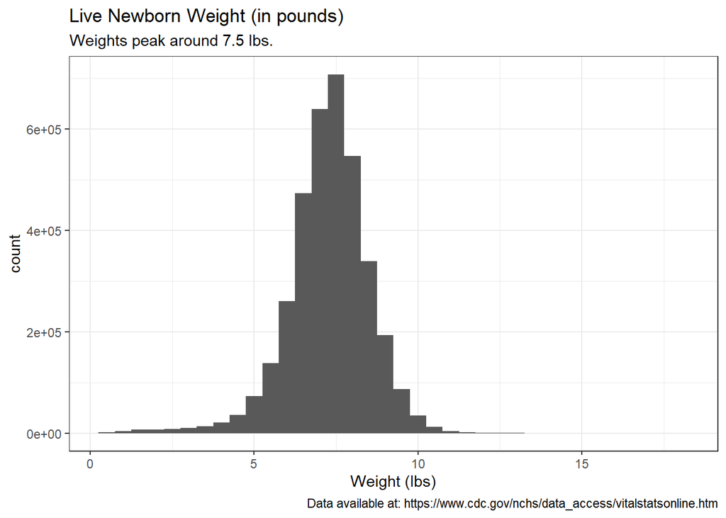

### 4B: Summarize the data (1 pt)

```
# A tibble: 1 × 3
  mean_weight    sd       n
        <dbl> <dbl>   <int>
1        7.26  561. 3616658
```

## Exercise 5: Birthweights and Recorded Sex

Split the distribution of newborn weights up by the recorded sex of the newborn and interpret what you see.

### 5A: Visualize the data (2 pt)

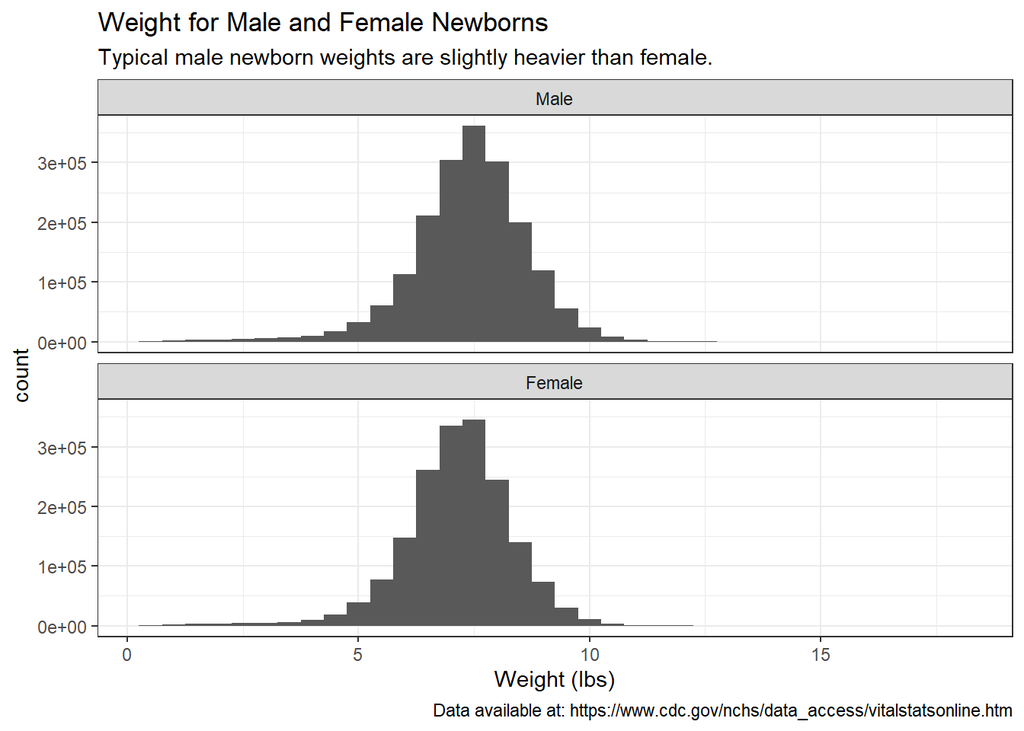

### 5B: Summarize the data (1 pt)

```
# A tibble: 2 × 4
  sex    mean_weight    sd       n
  <fct>        <dbl> <dbl>   <int>
1 Male          7.39  572. 1849572
2 Female        7.14  544. 1767086
```

### 5C: Interpret the data (1-2 sentences each; 2 pt total)

- Description: What is a good description of the difference in distribution of weights for male- and female-recorded newborns?
- Causal Understanding: Without further knowledge or assumptions, this data could be consistent with a world in which the weight of a newborn influences the recording of sex, with a world in which the sex of a newborn directly (or fetus beforehand) influences its weight, or a world in which neither sex nor weight directly influence each other. Write two single sentence stories that could produce the pattern seen (and potentially setting aside pre-existing understanding of biological development or sex determinations at birth).
- Prediction: There is a difference in typical weights based on recorded sex in this dataset. How well do you think you can predict the recorded gender of a newborn based on its weight?

## Exercise 6: Birthweights and Smoking in Pregnancy

Cigarette smoking during pregnancy is a issue that has been of great interest in the biomedical research world – and at times a source of guilt and stigma for pregnant women. Have a look at the distribution of newborn weights for mothers who did and did not report smoking during pregnancy.

Hint for visualization: Check how to remove outliers from boxplots.

### 6A: Visualize the data (2 pt)

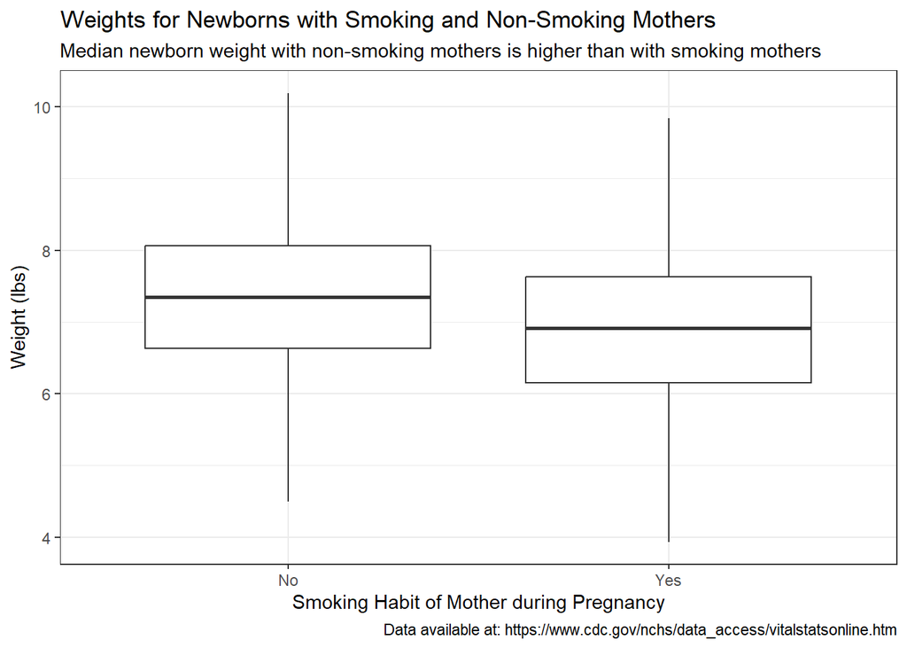

### 6B: Summarize the data (1 pt)

```
# A tibble: 2 × 3
  cig_rec median_weight       n
  <fct>           <dbl>   <int>
1 No               7.35 3382406
2 Yes              6.91  234252
```

### 6C: Interpreting the data (1-3 sentences each; 2 pt total):

- Description: How does the pattern of newborn weights differ for those whose mothers were smokers compared to those whose mothers were nonsmokers?
- Causal Understanding: What are two different causal stories or explanations for this pattern of data? In particular, consider at least one story where smoking does not lead to lower birthweight, but which is consistent with the data. Which story is more likely based on your prior knowledge?
- Prediction: Based just on the smoking habits of mothers, how well do you think you could predict the weight of newborn infants? In other words, are the children of women who smoked in pregnancy always small? Consider the range of weights for both groups.

## Exercise 7: Birthweights and Food Assistance

In the US, the Special Supplemental Nutrition Program for Women, Infants, and Children (or [WIC](https://www.fns.usda.gov/wic)) is one of the most widespread welfare programs offered by the federal government. Almost 7 million people used WIC in 2018. One of the stated goals of WIC is to enhance the health outcomes of mothers and children. One things you might think to do given this goal is to naively check out the distribution of newborn weights based on whether mothers used WIC or not. Check this out.

Hint for visualization: Check how to remove outliers from boxplots.

### 7A: Visualize the data (2 pt)

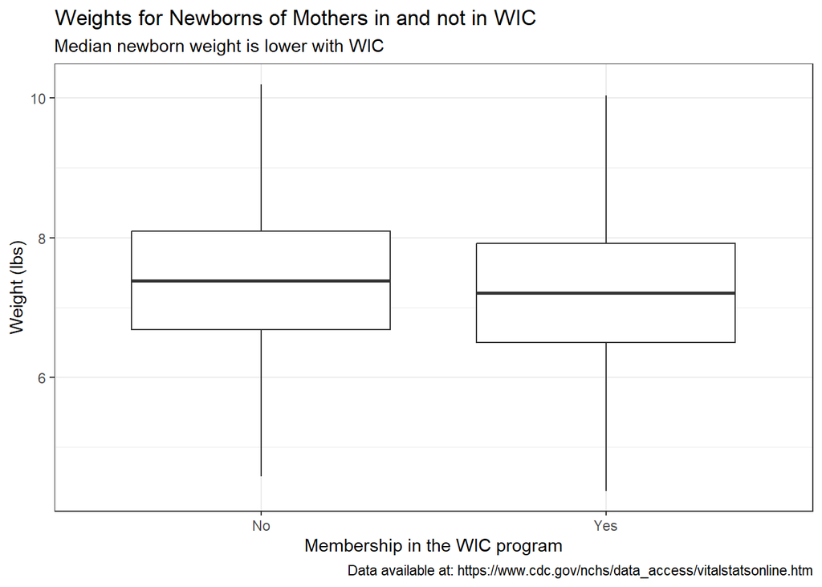

### 7B: Summarize the data (1 pt)

```
# A tibble: 2 × 3
  wic   median_weight       n
  <fct>         <dbl>   <int>
1 No             7.39 2315459
2 Yes            7.21 1301199
```

### 7C: Interpreting the data (1-3 sentences each; 2 pt total):

- Description: How does the pattern of newborn weights differ for those whose mothers were or were not in WIC?
- Causal Understanding: This data on its own is not good evidence that the WIC program is bad for maternal or fetal health. Why not? What is an alternative story that accounts for the pattern?
- Prediction: This data isn’t good evidence that WIC hinders maternal or fetal health, but does that mean that knowing if someone is using WIC would be useless in predicting the birth weight of their future newborn? Why or why not?

## Exercise 8: Birthweight and premie status

Many parents worry that having a premie – or an infant born “early” is dangerous. Indeed, there is a lot of research looking into the risks of early and very early births. But one thing to consider is that early births are not *always* a cause for alarm. Let’s consider how preterm birth relates in particular to low birth weight status. Recall that preterm is defined here as 37 weeks or earlier.

Hint for visualization: Check how to create stacked barplots with *proportions*.

### 8A: Visualize the data (2 pt)

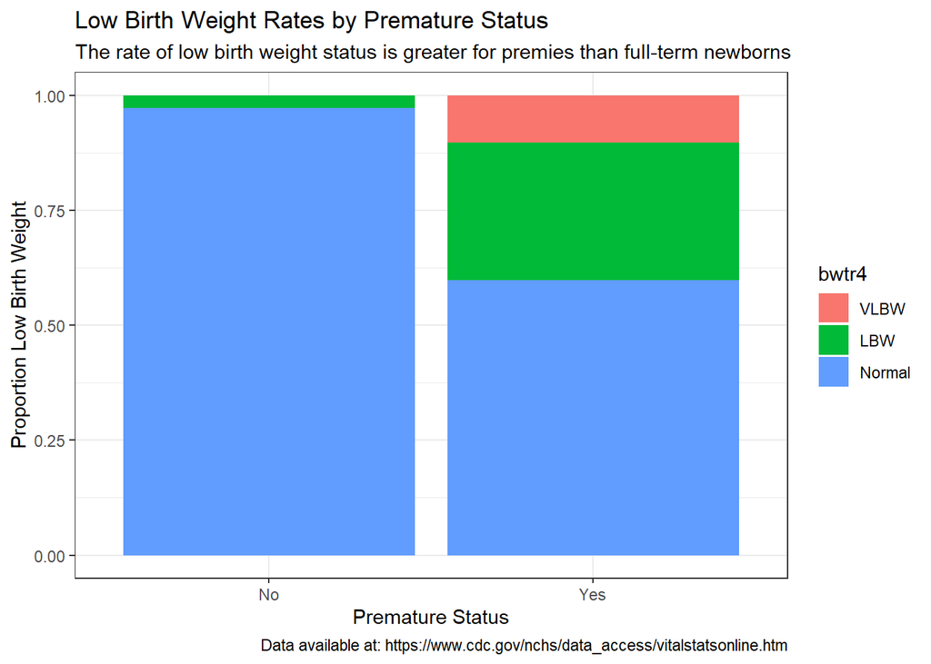

### 8B: Summarize the data (1 pt)

```
# A tibble: 6 × 3
# Groups:   preterm [2]
  preterm bwtr4        n
  <fct>   <fct>    <int>
1 No      VLBW      1382
2 No      LBW      89865
3 No      Normal 3163429
4 Yes     VLBW     37279
5 Yes     LBW     108512
6 Yes     Normal  216191
```

### 8C: Interpreting the data (1-2 sentences each; 2 pt total)::

- Description: What is a good description of the difference in distributions of (very) low birth weight status for premature and non-premature newborns?
- Causal Understanding: What are two different causal stories or explanations that could help explain this pattern of data (you can set aside or stretch your understanding of biological development)?
- Prediction: If you wanted to use this data to build a model that predicts if a newborn will be low birth weight based solely on their premature status, what would the most likely prediction be for either case?

# Reflection on Data Exploration

In this assignment, you have looked at some very serious, real data that has been collected from literally millions of people. It is important to think about the potential uses and limitations of this kind of data in terms of describing, understanding, and predicting patterns and outcomes in newborn health (or importantly maternal health!). Additionally, it is crucial to think deeply about the provenance of specific data sets and the ethics of using them.

The data set that you looked at is publicly available through the National Center for Vital Statistics, a part of the Centers for Disease Control (the CDC). This data set is intended to represent information about all births that occur in the US (in this case in 2018). The vast majority of births in the US are thought to be officially recorded and are detailed in this data set.

Having a birth record filed is crucial for many activities later in life, and is often necessary to demonstrate eligibility for US citizenship among other things. While most medical data requires consent to collect and share under US law, particularly under HIPAA (The Health Insurance Portability and Accountability Act), birth records are not officially considered protected health information, because they serve “vital” public health needs in the US.

For every recorded live birth, US states (and their representatives at health institutions) record information in a form that looks like [this](https://www.cdc.gov/nchs/data/dvs/birth11-03final-ACC.pdf). These records include a lot of different entries, including some very sensitive things about the background and health of the newborn and their family! This information is sent to the federal government and collated to form the complete data set of live births for each year. You only looked at part of the data set, but the full data set includes literally hundreds of features describing each birth in the US. While the publicly accessible version of this data removes the location of births and names, it still includes features like the exact time of birth and more than enough information to re-identify individuals. Biomedical researchers working for the government or major institutions can sometimes gain access to versions of the data with locations and names intact.

Versions of this data set (especially smaller subsets of it) are used commonly by data scientists and in textbooks and educational programs like this INFO course. Thousands of other students have looked at this data or similar versions of it. However, given all you know about birth records, you might want to consider whether it was actually *ethical* to use this data. Consider the three guiding ethical documents presented in class:

- [The ASA Ethical Guidelines](https://www.amstat.org/your-career/ethical-guidelines-for-statistical-practice)
- [The ACM Code of Ethics](https://www.acm.org/code-of-ethics)
- [The Feminist Data Manifest-No](https://www.manifestno.com/home)

In each of these documents, find at least one principle or statement that is related to *consent* when using human data. After finding each principle or statement, consider: Was it ethically problematic to complete this assignment in the framework that the document rests on? Note that there are gradient scales to what is or is not ethical – you may decide that completing this assignment was not strictly-speaking ethical. Keep in mind that completing similar assignments (and working with similar data in industry and public service) is currently common-place, and that you yourself were under some amount of pressure to complete this assignment. The instructor is personally terrified of the use of such data sets, but feels that it is ultimately more ethical to ensure that students are aware of their existence and use.

### Exercise 9 A: ASA Ethical Guidelines (2 pt)

What is a statement related to consent in the ASA guidelines?

Think about that statement and the context of the US birth record data. Is using this data ethically problematic based on your interpretation of this principle? How do you know? If your answer is “I don’t know”, what info would you need to determine this?

### Exercise 9 B: ACM Code of Ethics (2 pt)

What is a statement related to consent in the ACM Code?

Think about that statement and the context of the US birth record data. Is using this data ethically problematic based on your interpretation of this principle? How do you know? If your answer is “I don’t know”, what info would you need to determine this?

### Exercise 9 C: The Feminist Data Manifest-No (2 pt)

What is a statement related to consent in the Manifest-No?

Think about that statement and the context of the US birth record data. The manifest-no isn’t really a list of principles per se, but a list of things that people refuse to do *based* on principles. If you sign on to the Manifest-No, is using the US births data ethically problematic?

# That’s all!

When you have completed this assignment, make sure to render it as an html file. Check that the html file looks as you expect and upload the html report. If you do not complete the assignment and are unable to render the document, you can submit the .qmd for partial credit.